# Cross validation of the SNP-Gene-Bacteria data in 2 cities

## Step 1: Data preprocessing

### 1.1 Import the necessary libraries

```python
import pandas as pd
import numpy as np
import matplotlib.pyplot as plt
```

### 1.2 Load the data

Load the filtered full dataset and check the first few rows of the data.

> The folder containing all the data to be used is too large, thus the data is not included in the repository, see [README](https://github.com/Lucas04-nhr/SNP-Analysis/blob/main/README.md#structure-of-the-result-directory) to check the data source.

> The "Bacteria" column has not been replaced by the real names yet.

```python
full_data_bj = pd.read_csv('result/analysis/cross_validation/bac_age_BJ.csv')
full_data_gz = pd.read_csv('result/analysis/cross_validation/bac_age_GZ.csv')
```

```python
full_data_bj.head()
```

|  | CHR | SNP | UNADJ | GC | BONF | HOLM | SIDAK_SS | SIDAK_SD | FDR_BH | FDR_BY | Bacteria |
| --- | --- | --- | --- | --- | --- | --- | --- | --- | --- | --- | --- |
| 0 | 4 | 4:8609098 | 1.052000e-70 | 0.000003 | 1.119000e-63 | 1.119000e-63 | inf | inf | 1.119000e-63 | 1.874000e-62 | 38 |
| 1 | 20 | 20:30977589 | 1.002000e-69 | 0.000003 | 1.065000e-62 | 1.065000e-62 | inf | inf | 5.324000e-63 | 8.920000e-62 | 38 |
| 2 | 18 | 18:64718990 | 1.591000e-65 | 0.000012 | 1.691000e-58 | 1.691000e-58 | inf | inf | 5.638000e-59 | 9.447000e-58 | 38 |
| 3 | HG1523_PATCH | HG1523_PATCH:43470 | 1.057000e-65 | 0.000001 | 1.123000e-58 | 1.123000e-58 | inf | inf | 7.891000e-59 | 1.322000e-57 | 17 |
| 4 | 26 | 26:12121 | 2.227000e-65 | 0.000028 | 2.367000e-58 | 2.367000e-58 | inf | inf | 7.891000e-59 | 1.322000e-57 | 17 |

```python
full_data_gz.head()
```

|  | CHR | SNP | UNADJ | GC | BONF | HOLM | SIDAK_SS | SIDAK_SD | FDR_BH | FDR_BY | Bacteria |
| --- | --- | --- | --- | --- | --- | --- | --- | --- | --- | --- | --- |
| 0 | 18 | 18:107881 | 1.282000e-52 | 0.000008 | 7.951000e-46 | 7.951000e-46 | inf | inf | 7.951000e-46 | 1.289000e-44 | 4 |
| 1 | GL000225.1 | GL000225.1:63186 | 2.544000e-48 | 0.000003 | 1.579000e-41 | 1.579000e-41 | inf | inf | 1.579000e-41 | 2.560000e-40 | 45 |
| 2 | GL000225.1 | GL000225.1:63182 | 5.185000e-48 | 0.000009 | 3.217000e-41 | 3.217000e-41 | inf | inf | 1.608000e-41 | 2.609000e-40 | 45 |
| 3 | HG2069_PATCH | HG2069_PATCH:279669 | 1.065000e-45 | 0.000037 | 6.609000e-39 | 6.609000e-39 | inf | inf | 2.203000e-39 | 3.573000e-38 | 45 |
| 4 | 20 | 20:31067694 | 2.478000e-45 | 0.000038 | 1.538000e-38 | 1.538000e-38 | inf | inf | 3.844000e-39 | 6.234000e-38 | 45 |

```python
full_bac_bj = pd.read_csv('data/export/FMGC.ge/Beijing.csv')
full_bac_gz = pd.read_csv('data/export/FMGC.ge/Guangzhou.csv')
```

```python
full_bac_bj.head()
```

|  | Genus | BJ001 | BJ002 | BJ004 | BJ005 | BJ006 | BJ008 | BJ013 | BJ014 | BJ015 | ... | BJ214 | BJ215 | BJ216 | BJ217 | BJ218 | BJ219 | BJ220 | BJ222 | BJ223 | BJ224 |
| --- | --- | --- | --- | --- | --- | --- | --- | --- | --- | --- | --- | --- | --- | --- | --- | --- | --- | --- | --- | --- | --- |
| 0 | 2-12-FULL-35-15 | 0.000000 | 0.0 | 0.000000 | 0.000000 | 0.000000 | 0.000000 | 0.000000 | 0.001802 | 0.000000 | ... | 0.000000 | 0.000000 | 0.000000 | 0.000000 | 0.00000 | 0.000000 | 0.000000 | 0.000000 | 0.000000 | 0.00000 |
| 1 | Abiotrophia | 0.000000 | 0.0 | 0.000000 | 0.000000 | 0.000000 | 0.000000 | 0.000000 | 0.000000 | 0.000000 | ... | 0.000000 | 0.000000 | 0.000000 | 0.000000 | 0.00000 | 0.000000 | 0.000000 | 0.000000 | 0.000000 | 0.00000 |
| 2 | Acetatifactor | 0.000000 | 0.0 | 0.000000 | 0.000000 | 0.000000 | 0.000000 | 0.000000 | 0.000000 | 0.000000 | ... | 0.000000 | 0.000000 | 0.000000 | 0.000000 | 0.00000 | 0.000000 | 0.000000 | 0.000000 | 0.000000 | 0.00000 |
| 3 | Acetobacter | 0.000000 | 0.0 | 0.000000 | 0.000000 | 0.000000 | 0.000000 | 0.000000 | 0.000000 | 0.000000 | ... | 0.000000 | 0.000000 | 0.000000 | 0.000000 | 0.00000 | 0.000000 | 0.000000 | 0.000000 | 0.000000 | 0.00000 |
| 4 | Acidovorax | 0.000771 | 0.0 | 0.000267 | 0.000776 | 0.000583 | 0.001942 | 0.000264 | 0.000468 | 0.000566 | ... | 0.000129 | 0.000209 | 0.000932 | 0.000815 | 0.00076 | 0.000497 | 0.001119 | 0.001657 | 0.000462 | 0.00092 |

5 rows × 202 columns

```python
full_bac_gz.head()
```

|  | Genus | GZ001 | GZ002 | GZ003 | GZ004 | GZ005 | GZ006 | GZ007 | GZ008 | GZ009 | ... | GZ228 | GZ229 | GZ231 | GZ232 | GZ233 | GZ234 | GZ235 | GZ236 | GZ237 | GZ238 |
| --- | --- | --- | --- | --- | --- | --- | --- | --- | --- | --- | --- | --- | --- | --- | --- | --- | --- | --- | --- | --- | --- |
| 0 | 21-14-0-10-47-8 | 0.000000 | 0.000000 | 0.000000 | 0.000000 | 0.000000 | 0.000000 | 0.000000 | 0.000000 | 0.000000 | ... | 0.000000 | 0.000000 | 0.000000 | 0.000000 | 0.000000 | 0.000000 | 0.000000 | 0.000000 | 0.000000 | 0.000000 |
| 1 | Abiotrophia | 0.000000 | 0.000000 | 0.000000 | 0.000000 | 0.000000 | 0.000000 | 0.000000 | 0.000000 | 0.000000 | ... | 0.000000 | 0.000000 | 0.000000 | 0.000000 | 0.000000 | 0.000000 | 0.000000 | 0.000000 | 0.000000 | 0.000000 |
| 2 | Achromobacter | 0.000000 | 0.000000 | 0.000263 | 0.000000 | 0.000000 | 0.000000 | 0.000000 | 0.000000 | 0.000000 | ... | 0.000000 | 0.000000 | 0.000000 | 0.000000 | 0.010991 | 0.002700 | 0.000000 | 0.029905 | 0.000000 | 0.004649 |
| 3 | Acidovorax | 0.000644 | 0.000195 | 0.000583 | 0.000432 | 0.000393 | 0.000391 | 0.000187 | 0.000448 | 0.000759 | ... | 0.000712 | 0.000519 | 0.000141 | 0.000313 | 0.001125 | 0.000699 | 0.000609 | 0.001400 | 0.000196 | 0.000532 |
| 4 | Acidovorax_A | 0.000000 | 0.000000 | 0.000000 | 0.000000 | 0.000000 | 0.000000 | 0.000000 | 0.000000 | 0.000000 | ... | 0.000000 | 0.000000 | 0.000000 | 0.000000 | 0.000000 | 0.000000 | 0.000000 | 0.000284 | 0.000000 | 0.000000 |

5 rows × 161 columns

### 1.3 Load the metadata of each bacteria

Load the metadata of each bacteria and check the first few rows of the data.

```python
bac_bj = pd.read_csv('result/analysis/top_bacteria/bacteria_BJ.csv')
bac_gz = pd.read_csv('result/analysis/top_bacteria/bacteria_GZ.csv')
```

```python
bac_bj.head()
```

|  | No. | Species |
| --- | --- | --- |
| 0 | 1 | Actinomyces oris |
| 1 | 2 | Aeromonas caviae |
| 2 | 3 | Alloprevotella sp015259235 |
| 3 | 4 | Anaerococcus nagyae |
| 4 | 5 | Corynebacterium kefirresidentii |

```python
bac_gz.head()
```

|  | No. | Species |
| --- | --- | --- |
| 0 | 1 | Acinetobacter baumannii |
| 1 | 2 | Aeromonas caviae |
| 2 | 3 | Anaerococcus nagyae |
| 3 | 4 | Corynebacterium kefirresidentii |
| 4 | 5 | Corynebacterium macginleyi |

### 1.4 Replace the "Bacteria" column with the real names

Replace the "Bacteria" column with the real names of the bacteria.

```python
# Merge full_data_bj with bac_bj to replace Bacteria column with real names
full_data_bj = full_data_bj.merge(bac_bj, left_on='Bacteria', right_on='No.', how='left')

# Drop the original Bacteria column and the No. column from bac_bj
full_data_bj = full_data_bj.drop(columns=['Bacteria', 'No.'])

# Rename the Species column to Bacteria
full_data_bj = full_data_bj.rename(columns={'Species': 'Bacteria'})

# Display the updated dataframe
full_data_bj.head()
```

|  | CHR | SNP | UNADJ | GC | BONF | HOLM | SIDAK_SS | SIDAK_SD | FDR_BH | FDR_BY | Bacteria |
| --- | --- | --- | --- | --- | --- | --- | --- | --- | --- | --- | --- |
| 0 | 4 | 4:8609098 | 1.052000e-70 | 0.000003 | 1.119000e-63 | 1.119000e-63 | inf | inf | 1.119000e-63 | 1.874000e-62 | Veillonella parvula_A |
| 1 | 20 | 20:30977589 | 1.002000e-69 | 0.000003 | 1.065000e-62 | 1.065000e-62 | inf | inf | 5.324000e-63 | 8.920000e-62 | Veillonella parvula_A |
| 2 | 18 | 18:64718990 | 1.591000e-65 | 0.000012 | 1.691000e-58 | 1.691000e-58 | inf | inf | 5.638000e-59 | 9.447000e-58 | Veillonella parvula_A |
| 3 | HG1523_PATCH | HG1523_PATCH:43470 | 1.057000e-65 | 0.000001 | 1.123000e-58 | 1.123000e-58 | inf | inf | 7.891000e-59 | 1.322000e-57 | Porphyromonas pasteri |
| 4 | 26 | 26:12121 | 2.227000e-65 | 0.000028 | 2.367000e-58 | 2.367000e-58 | inf | inf | 7.891000e-59 | 1.322000e-57 | Porphyromonas pasteri |

```python
# Merge full_data_gz with bac_gz to replace Bacteria column with real names
full_data_gz = full_data_gz.merge(bac_gz, left_on='Bacteria', right_on='No.', how='left')

# Drop the original Bacteria column and the No. column from bac_gz
full_data_gz = full_data_gz.drop(columns=['Bacteria', 'No.'])

# Rename the Species column to Bacteria
full_data_gz = full_data_gz.rename(columns={'Species': 'Bacteria'})

# Display the updated dataframe
full_data_gz.head()
```

|  | CHR | SNP | UNADJ | GC | BONF | HOLM | SIDAK_SS | SIDAK_SD | FDR_BH | FDR_BY | Bacteria |
| --- | --- | --- | --- | --- | --- | --- | --- | --- | --- | --- | --- |
| 0 | 18 | 18:107881 | 1.282000e-52 | 0.000008 | 7.951000e-46 | 7.951000e-46 | inf | inf | 7.951000e-46 | 1.289000e-44 | Corynebacterium kefirresidentii |
| 1 | GL000225.1 | GL000225.1:63186 | 2.544000e-48 | 0.000003 | 1.579000e-41 | 1.579000e-41 | inf | inf | 1.579000e-41 | 2.560000e-40 | Vibrio metschnikovii |
| 2 | GL000225.1 | GL000225.1:63182 | 5.185000e-48 | 0.000009 | 3.217000e-41 | 3.217000e-41 | inf | inf | 1.608000e-41 | 2.609000e-40 | Vibrio metschnikovii |
| 3 | HG2069_PATCH | HG2069_PATCH:279669 | 1.065000e-45 | 0.000037 | 6.609000e-39 | 6.609000e-39 | inf | inf | 2.203000e-39 | 3.573000e-38 | Vibrio metschnikovii |
| 4 | 20 | 20:31067694 | 2.478000e-45 | 0.000038 | 1.538000e-38 | 1.538000e-38 | inf | inf | 3.844000e-39 | 6.234000e-38 | Vibrio metschnikovii |

## Step 2: Data analysis

### 2.1 Check the distribution of the target variable

#### 2.1.1 p-value threshold

```python
# See the 100th p-value
print('100th p-value of Beijing:', full_data_bj.loc[99, 'FDR_BY'])
```

```
100th p-value of Beijing: 8.401e-47
```

```python
print('100th p-value of Guangzhou:', full_data_gz.loc[99, 'FDR_BY'])
```

```
100th p-value of Guangzhou: 4.185e-32
```

#### 2.1.2 Top-100 smallest FDR-BY p-values

```python
# Use list to store the top
bac_bj_top = full_data_bj['Bacteria'].head(100).unique()
bac_gz_top = full_data_gz['Bacteria'].head(100).unique()

# Fill the counts of each bacteria in the top 100 FDR_BY
count_bj = []
count_gz = []

# Count the number of bacteria in the top 100 FDR_BY that are in the top 100 bacteria

# Count the occurrences of each bacteria in the top 100 rows
count_bj = full_data_bj['Bacteria'].head(100).value_counts().reindex(bac_bj_top, fill_value=0).tolist()

# Count the number of bacteria in the top 100 FDR_BY that are in the top 100 bacteria

count_gz = full_data_gz['Bacteria'].head(100).value_counts().reindex(bac_gz_top, fill_value=0).tolist()

# Create a dataframe to store the counts
count_bj = pd.DataFrame({'Bacteria': bac_bj_top, 'Count': count_bj})
count_gz = pd.DataFrame({'Bacteria': bac_gz_top, 'Count': count_gz})

# Sort the dataframe by the counts
count_bj = count_bj.sort_values(by='Count', ascending=False)
count_gz = count_gz.sort_values(by='Count', ascending=False)
```

```python
# Print the top 10 bacteria in BJ
count_bj.head(10)
```

|  | Bacteria | Count |
| --- | --- | --- |
| 1 | Porphyromonas pasteri | 64 |
| 0 | Veillonella parvula_A | 36 |

```python
count_gz.head(10)
```

|  | Bacteria | Count |
| --- | --- | --- |
| 1 | Vibrio metschnikovii | 48 |
| 3 | Unclassified_A36_bin.27 | 20 |
| 0 | Corynebacterium kefirresidentii | 16 |
| 6 | Acinetobacter baumannii | 7 |
| 2 | Staphylococcus epidermidis | 5 |
| 5 | Cutibacterium modestum | 3 |
| 4 | Lawsonella clevelandensis_A | 1 |

#### 2.1.3 See the unique bacteria count of each city

```python
# See the unique bacteria count in Beijing
full_data_bj['Bacteria'].nunique()
```

```
36
```

```python
# See the unique bacteria count in Guangzhou
full_data_gz['Bacteria'].nunique()
```

```
46
```

#### 2.1.4 Draw a venn diagram of the unique bacteria count of each city

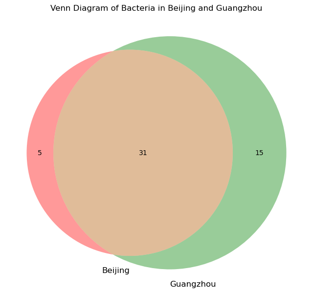

```python
# Draw the Venn diagram

from matplotlib_venn import venn2

# Create a set for all the bacteria in BJ and GZ
set_bj = set(full_data_bj['Bacteria'].unique())
set_gz = set(full_data_gz['Bacteria'].unique())

# Create a Venn diagram
plt.figure(figsize=(8, 8), dpi=100)
venn2([set_bj, set_gz], ('Beijing', 'Guangzhou'))
plt.title('Venn Diagram of Bacteria in Beijing and Guangzhou')
plt.savefig('./venn_diagram_bac_age.pdf')
plt.show()
```

### 2.2 Set the threshold of the p-value

```python
# Set the threshold of FDR_BY in Beijing
threshold_bj = []
for i in range(1, 21):
  num = 5 * i
  print(f'Threshold of FDR_BY in Beijing: {num}')
  print(full_data_bj.loc[num-1, 'FDR_BY'])
  threshold_bj.append(full_data_bj.loc[num-1, 'FDR_BY'])
```

```
Threshold of FDR_BY in Beijing: 5
1.322e-57
Threshold of FDR_BY in Beijing: 10
2.046e-57
Threshold of FDR_BY in Beijing: 15
9.999000000000001e-57
Threshold of FDR_BY in Beijing: 20
1.653e-56
Threshold of FDR_BY in Beijing: 25
2.4300000000000007e-56
Threshold of FDR_BY in Beijing: 30
1.716e-55
Threshold of FDR_BY in Beijing: 35
7.196e-55
Threshold of FDR_BY in Beijing: 40
2.6219999999999997e-54
Threshold of FDR_BY in Beijing: 45
9.413e-54
Threshold of FDR_BY in Beijing: 50
3.5279999999999993e-53
Threshold of FDR_BY in Beijing: 55
9.487e-53
Threshold of FDR_BY in Beijing: 60
3.907e-52
Threshold of FDR_BY in Beijing: 65
2.961e-51
Threshold of FDR_BY in Beijing: 70
3.735e-50
Threshold of FDR_BY in Beijing: 75
5.294000000000001e-50
Threshold of FDR_BY in Beijing: 80
3.016e-49
Threshold of FDR_BY in Beijing: 85
1.171e-48
Threshold of FDR_BY in Beijing: 90
4.027e-48
Threshold of FDR_BY in Beijing: 95
1.281e-47
Threshold of FDR_BY in Beijing: 100
8.401e-47
```

```python
print(threshold_bj)
```

```
[1.322e-57, 2.046e-57, 9.999000000000001e-57, 1.653e-56, 2.4300000000000007e-56, 1.716e-55, 7.196e-55, 2.6219999999999997e-54, 9.413e-54, 3.5279999999999993e-53, 9.487e-53, 3.907e-52, 2.961e-51, 3.735e-50, 5.294000000000001e-50, 3.016e-49, 1.171e-48, 4.027e-48, 1.281e-47, 8.401e-47]
```

```python
# Set the threshold of FDR_BY in Guangzhou
threshold_gz = []
for i in range(1, 21):
  num = 5 * i
  print(f'Threshold of FDR_BY in Guangzhou: {num}')
  print(full_data_gz.loc[num-1, 'FDR_BY'])
  threshold_gz.append(full_data_gz.loc[num-1, 'FDR_BY'])
```

```
Threshold of FDR_BY in Guangzhou: 5
6.234e-38
Threshold of FDR_BY in Guangzhou: 10
1.085e-36
Threshold of FDR_BY in Guangzhou: 15
8.481000000000001e-36
Threshold of FDR_BY in Guangzhou: 20
8.529000000000001e-35
Threshold of FDR_BY in Guangzhou: 25
9.158e-35
Threshold of FDR_BY in Guangzhou: 30
2.538e-34
Threshold of FDR_BY in Guangzhou: 35
5.447e-34
Threshold of FDR_BY in Guangzhou: 40
6.7e-34
Threshold of FDR_BY in Guangzhou: 45
8.874e-34
Threshold of FDR_BY in Guangzhou: 50
1.244e-33
Threshold of FDR_BY in Guangzhou: 55
2.022e-33
Threshold of FDR_BY in Guangzhou: 60
3.0189999999999997e-33
Threshold of FDR_BY in Guangzhou: 65
4.274e-33
Threshold of FDR_BY in Guangzhou: 70
4.716e-33
Threshold of FDR_BY in Guangzhou: 75
8.666e-33
Threshold of FDR_BY in Guangzhou: 80
1.462e-32
Threshold of FDR_BY in Guangzhou: 85
1.812e-32
Threshold of FDR_BY in Guangzhou: 90
2.078e-32
Threshold of FDR_BY in Guangzhou: 95
2.928e-32
Threshold of FDR_BY in Guangzhou: 100
4.185e-32
```

```python
print(threshold_gz)
```

```
[6.234e-38, 1.085e-36, 8.481000000000001e-36, 8.529000000000001e-35, 9.158e-35, 2.538e-34, 5.447e-34, 6.7e-34, 8.874e-34, 1.244e-33, 2.022e-33, 3.0189999999999997e-33, 4.274e-33, 4.716e-33, 8.666e-33, 1.462e-32, 1.812e-32, 2.078e-32, 2.928e-32, 4.185e-32]
```

We'll use a plot to visualize the cross-validation results of the SNP-Gene-Bacteria data in the two cities.

#### 2.2.1 Perform the cross-validation

Numbers of data in each city:

- Beijing: 36 bacterias with 100 SNPs each, total 3600 data
- Guangzhou: 46 bacterias with 100 SNPs each, total 4600 data

```python
# Prepare the x label
x_label = [5, 10, 15, 20, 25, 30, 35, 40, 45, 50, 55, 60, 65, 70, 75, 80, 85, 90, 95, 100]
```

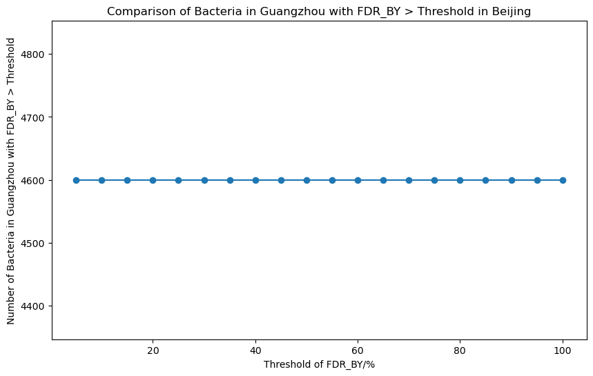

```python
threshold_compare_bj = []

for i in range(20):
  threshold_compare_bj.append(sum(full_data_gz['FDR_BY'] > threshold_bj[i]))

# Draw a line chart to visualize the comparison

plt.figure(figsize=(10, 6), dpi=100)
plt.plot(x_label, threshold_compare_bj, marker='o', label='Guangzhou')
plt.xlabel('Threshold of FDR_BY/%')
plt.ylabel('Number of Bacteria in Guangzhou with FDR_BY > Threshold')
plt.title('Comparison of Bacteria in Guangzhou with FDR_BY > Threshold in Beijing')
# plt.legend()
plt.savefig('./threshold_compare_bj.pdf')
plt.show()
```

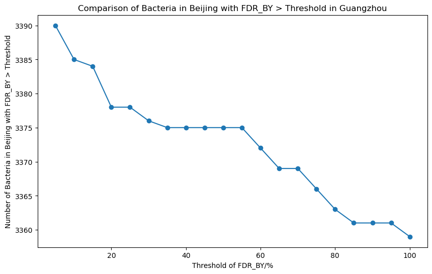

```python
threshold_compare_gz = []

for i in range(20):
  threshold_compare_gz.append(sum(full_data_bj['FDR_BY'] > threshold_gz[i]))

# Draw a line chart to visualize the comparison

plt.figure(figsize=(10, 6), dpi=100)
plt.plot(x_label, threshold_compare_gz, marker='o', label='Beijing')
plt.xlabel('Threshold of FDR_BY/%')
plt.ylabel('Number of Bacteria in Beijing with FDR_BY > Threshold')
plt.title('Comparison of Bacteria in Beijing with FDR_BY > Threshold in Guangzhou')
plt.savefig('./threshold_compare_gz.pdf')
plt.show()
```

The 2 figures above show the cross-validation results of the SNP-Gene-Bacteria data in the two cities.

The higher the point in the graph, the lower the overlap between the two cities at the corresponding threshold level.

### 2.3 Cross-validation

#### 2.3.1 Scatter plot of the 20 percentile thresholds in 2 cities

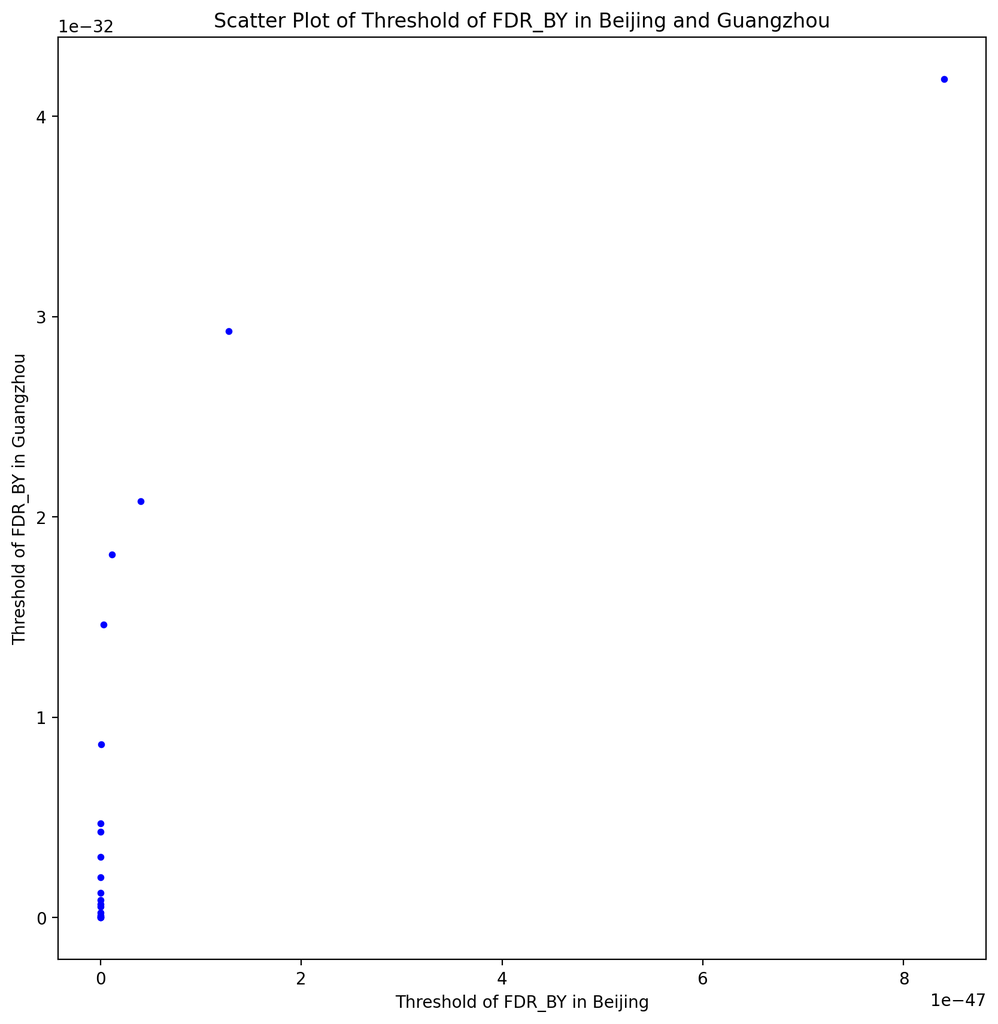

```python
# Draw the scatter plot of the threshold of FDR_BY in two cities
plt.figure(figsize=(10, 10), dpi=200)
plt.scatter(threshold_bj, threshold_gz, color='blue', s=10)
# plt.plot([min(threshold_bj), max(threshold_bj)], [min(threshold_bj), max(threshold_bj)], color='red', linestyle='--')
plt.xlabel('Threshold of FDR_BY in Beijing')
plt.ylabel('Threshold of FDR_BY in Guangzhou')
plt.title('Scatter Plot of Threshold of FDR_BY in Beijing and Guangzhou')
plt.savefig('./scatter_threshold_bac_age.pdf')
plt.show()
```

From the scatter plot, we can see that the thresholds of the two cities have a significant difference.

So, the next step is to see the cross-validation results of the Bac-Gene data in the two cities.

#### 2.3.2 Filter the gene data out with the top

> The gene data is filtered out from the top 5 SNPs of each bacteria. See the script [here](https://github.com/Lucas04-nhr/SNP-Analysis/blob/main/script/snp_fetch.py).

```python
gene_bj = pd.read_csv('result/analysis/gene_allocation/bac_age_BJ_snp_gene.csv')
gene_gz = pd.read_csv('result/analysis/gene_allocation/bac_age_GZ_snp_gene.csv')
```

```python
gene_bj.head()
```

|  | SNP | BONF | Bacteria | known_snp | external_name | gene_id | biotype | description |
| --- | --- | --- | --- | --- | --- | --- | --- | --- |
| 0 | 1:205986021 | 4.706000e-19 | Vibrio metschnikovii | 1 | RAB7B | ENSG00000276600 | protein_coding | RAB7B, member RAS oncogene family [Source:HGNC... |
| 1 | 2:131626435 | 7.709000e-11 | Unclassified_BJ026_bin.8 | 1 | POTEKP | ENSG00000204434 | transcribed_unprocessed_pseudogene | POTE ankyrin domain family member K, pseudogen... |
| 2 | 2:225227256 | 3.572000e-19 | Lawsonella clevelandensis_A | 0 | NaN | NaN | NaN | NaN |
| 3 | 2:241245521 | 1.154000e-11 | Staphylococcus epidermidis | 0 | HDLBP | ENSG00000115677 | protein_coding | high density lipoprotein binding protein [Sour... |
| 4 | 4:8609098 | 1.119000e-63 | Veillonella parvula_A | 1 | CPZ | ENSG00000109625 | protein_coding | carboxypeptidase Z [Source:HGNC Symbol;Acc:HGN... |

```python
gene_gz.head()
```

|  | SNP | BONF | Bacteria | known_snp | external_name | gene_id | biotype | description |
| --- | --- | --- | --- | --- | --- | --- | --- | --- |
| 0 | 3:173901364 | 3.890000e-37 | Staphylococcus epidermidis | 1 | NLGN1 | ENSG00000169760 | protein_coding | neuroligin 1 [Source:HGNC Symbol;Acc:HGNC:14291] |
| 1 | 4:99041416 | 3.775000e-35 | Lawsonella clevelandensis_A | 1 | METAP1 | ENSG00000164024 | protein_coding | methionyl aminopeptidase 1 [Source:HGNC Symbol... |
| 2 | 4:169480275 | 1.547000e-18 | Kocuria marina | 1 | NEK1 | ENSG00000137601 | protein_coding | NIMA related kinase 1 [Source:HGNC Symbol;Acc:... |
| 3 | 5:235306 | 3.824000e-21 | Cutibacterium granulosum | 1 | NaN | ENSG00000286001 | protein_coding | novel protein |
| 4 | 5:49600762 | 6.969000e-35 | Acinetobacter baumannii | 1 | NaN | NaN | NaN | NaN |

#### 2.3.3 See the unique gene count of each city

```python
gene_bj['gene_id'].nunique()
```

```
10
```

```python
gene_gz['gene_id'].nunique()
```

```
11
```

#### 2.3.4 Draw a venn diagram of the unique gene count of each city

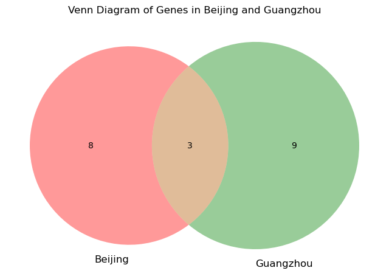

```python
# Draw the Venn diagram

# Create a set for all the genes in BJ and GZ
set_gene_bj = set(gene_bj['gene_id'].unique())
set_gene_gz = set(gene_gz['gene_id'].unique())

# Create a Venn diagram
plt.figure(figsize=(8, 8), dpi=100)
venn2([set_gene_bj, set_gene_gz], ('Beijing', 'Guangzhou'))
plt.title('Venn Diagram of Genes in Beijing and Guangzhou')
plt.savefig('./venn_diagram_gene_age.pdf')
plt.show()
```